# Cuadro de Valores de Micro robots

Martínez Meléndez José de Jesús

08 / Marzo / 2021

Naturaleza: Durante la historia el hombre ha sentido fascinación por las máquinas y dispositivos capaces de imitar las funciones y los movimientos de los seres vivos. La tecnología hoy en día avance a pasos agigantados y desde hace años se ha creado la primera MICROMÁQUINA que es un conjunto de mecanismos de tamaño reducido con la finalidad de realizar trabajo desde rangos de milímetros a nanómetros en su espacio y operaciones de trabajo. Sabemos que este sector industrial, la naturaleza ya está modificada por el hombre, sin embargo, para llegar hasta el producto final, también se tienen materias primas y estas materias también salen de la tierra. Los Microrobots tienen diferentes diseños, los más comunes: Tubos, esferas, hélices y espirales. Cada uno de ellos tienen diversas capas, donde el interior está hecho de metales como el platino, titanio, oro, hierro, cromo, niquel y grafito. Para el uso médico pueden estar hechos de capas de hidrogel biocompatible (Alcohol, hidrogel y agua). Los diseños micro pueden ser en algunos casos, complejos de diseñar pero por su reducido tamaño, no se necesitan grandes cantidades lo cual se puede producir mucho con poca materia. (Rodriguez-Franco, P. 2017) Valor de Uso: La tecnología a escala micro sigue siendo investigada y desarrollada para alcanzar su perfección a la hora de usarla en la vida real y satisfacer las necesidades que surjan. Hasta el día de hoy en la medicina: son de ayuda en cirugías en donde se introducen en el cuerpo humano, para realizar tareas como limpiar arterias de obstrucciones o viajan en el torrente sanguíneo para realizar tareas como suministrar medicinas o encontrar toxinas. En un futuro están desarrollando los microbots para su uso en la polinización de cultivos como lo hacen las abejas o en la agricultura para recoger información y datos de cultivos. O en la industria química: se han desarrollado microbots para purificar el agua. Rocha, J. (08 de marzo del 2021). Microbots. Recuperado de https://www.robotsyrobotica.com/microbots/ Valor de Cambio: Al estar aún en desarrollo, no hay un intercambio entre comunidades o regiones como tal a gran escala, lo que si hay, es cooperación a gran escala como el proyecto financiado por la Unión Europea: MICRON (Miniaturised Co-operative Robots advancing towards the Nano range), financiado a través de la prioridad de tecnologías de sociedad de la información del VI Programa Marco (VIPM) ha logrado con éxito desarrollar un minúsculo robot para trabajar satisfactoriamente en experimentos médicos, de microensamblado y de fuerza atómica. https://cordis.europa.eu/article/id/25277-eu-project-creates-microrobots-/es Valor: SRI International está desarrollando para la fabricación de productos a gran escala. El DM3, Diamagnetic Micro Manipulation ha sido patentado por SRI donde la tecnología DM3 está disponible para que universidades y otros investigadores desarrollen sus propias propuestas. Ortiz, J. (18 de Abril del 2014). Microrobots para fabricación inteligente. Recuperado de https://www.cosasdearquitectos.com/2014/04/micro-robots-para-fabricacion-inteligente-de-objetos-3d/ Una de las empresas que está siguiendo al desarrollo de microbots es BairesDev -elegida por Clutch como la firma de mayor crecimiento en la región y distinguida como una de las 10 compañías con el mayor crecimiento de Silicon Valley. Azorin, P. (27 de noviembre del 2019). Microrobots cuando la realidad supera a la ficción. Recuperado de https://www.forbes.com.mx/microbots-cuando-la-realidad-supera-a-la-ficcion/ En la Escuela Politécnica Federal de Lausana y Bradley Nelson en ETH en Zurich, esta creando microbots que son similares a las bacterias, pueden transportarse a través del torrente sanguíneo y cambiar su forma en caso de necesitarse. Rocha, J. (08 de marzo del 2021). Microbots. Recuperado de https://www.robotsyrobotica.com/microbots/

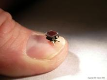

## Bibliografía

http://divulga.ibecbarcelona.eu/yo-nanorobot/#:~:text=Los%20investigadores%20han%20logrado%20fabricar,metales%20pesados%20en%20aguas%20residuales.&text=Estas%20estructuras%2C%20de%20decenas%20de,mitades%2C%20hechas%20de%20materiales%20distintos. https://www.robotsyrobotica.com/microbots/ https://www.forbes.com.mx/microbots-cuando-la-realidad-supera-a-la-ficcion/ https://cordis.europa.eu/article/id/25277-eu-project-creates-microrobots-/es